# McKenzie 2022 Parentage Assignment Log

```r
require(kableExtra)
require(gt)
require(gtsummary)
require(tidyverse)
require(magrittr)
```

# Summary

This notebook contains a log of all work to create the final pedigree for the 2022 South Fork McKenzie River Chinook salmon genetic pedigree study.

For each offspring year, assign parentage using two programs: *Cervus* and *Colony*. Then create a consensus pedigree between the two programs. Finally, combine offspring years into a final pedigree used for downstream analysis.

This is an R notebook. The .html version of this file is a fully rendered and interactive log. To view it, save the html and open in a browse. The .rmd version can be opened within R studio. To reproduce results or edit the analysis: clone the full repository onto tyour local machine and open the r project in rstudio. This will provide all needed data and objects.

# Rationale and Pedigree Years

This notebook is a log of all work to produce a pedigree of all Chinook Salmon released above Cougar Dam on the South Fork McKenzie River from 2007 - 2017 using potential offspring sampled from 2010 to 2020.

## Summary of Cohort Years

Previous reports and manuscripts evaluating the reintroduction of Chinook salmon above Cougar Dam on the South Fork McKenzie river have considered NOR salmon sampled from 2010 to 2015 as potential offspring of salmon released above Cougar Dam from 2007 - 2012.

Most Chinook salmon on the South Fork McKenzie express an age at maturity of 3 - 6 years. Therefore, previous reports (relying on 2010 - 2015 NOR returns) have inferred a pedigree for salmon released above the dam from 2007 - 2009. Results based on the pedigree of salmon released above Cougar Dam in 2010 were also provided along with the caveat that age 6 offspring were not yet evaluated and some results such as Total Lifetime Fitness and Cohort Replacement Rate were likely underestimates.

Continuing this work, we have since genotyped NOR salmon sampled on the South Fork McKenzie from 2016 to 2020, as well as salmon released above Cougar dam from 2013 to 2017. These new data allow us to complete the pedigree of salmon released above Cougar Dam in 2010, infer full pedigrees (and TLF) for salmon released above Cougar Dam from 2011 - 2014, and partial pedigrees for salmon released above the dam from 2015 - 2017.

## Inferring Pedigrees Again

Irrevocable updates to software packages used to assign parentage (COLONY) prevent us from exactly reproducing the approach used to infer the pedigrees used in previous reports. We chose to infer all pedigrees from parent years 2007 to 2017 (offspring year 2010 - 2020) from the raw genetic data using a consistent approach rather than simply combining previous pedigrees with those inferred from new data.

This means that parent year results from 2007-2010 and offspring year results from 2010 - 2015, that have previously been reported on may change. We will evaluate how much changes to the parentage assignment approach affect dwonstream summary statistics such as assignment rate, cohort replacement rate, and fitness for these years.

This approach has several advantages:  
(1) Trends - Results based on the pedigrees such as Cohort Replacement Rate and Total Lifetime Fitness suffer from the same biases across all years, allowing more confidence in the identification of year - year trends.  
(2) Fitness modeling - Similar to above, applying a consistent approach to pedigree inference gives us more power to identify predictors of fitness by allowing us to combine data from more years into a single analysis  
(3) Grandparentage and Great-Grandparentage: If a unified filtering and pedigree inference approach is used for the entire dataset, we can more confidently combine pedigrees inferred for a single offspring year with one another, allowing for a 3 (or perhaps even 4) generation pedigree. This means we can identify gradnparentage and great grandparentage, opening up the potential to address many important questions such as fitness effects of hatchery selection.  
(4) Minor Issues - In reproducing previous results, minor errors in code were identified. While these errors ultimately were expected to have little effect on the final pedigrees and results, inferring the pedigrees again allows us to fix these small errors and evaluate their effects. For example in the Cervus pedigrees, the software is run using a single parent year and a single offspring year, then the results are concatenated for all parent years within an offspring year. This renders the likelihoods incomparable. Likelihoods are used to break ties when inferring the cervus pedigree, but it likely never had a large effect because Colony is given priority in the consensus pedigree.

# Data Summary

Input data is available in the directories:  
“mckenzie_2022/parentage/CERVUS”  
“mckenzie_2022/parentage/COLONY”

- These directories contains inputs and outputs for/from Cervus and Colony
- Subdirectories are organized by offspring year, each subdirectory contains:
  - all data required to run Cervus and Colony for a given offspring year
  - unprocessed outputs from Cervus and Colony for a given offspring year
  - processed Cervus and Colony pedigrees for a given offspring year
  - note that the same parent can occur across multiple offspring years, so all information for a given parent may be spread across multiple subdirectories

```r
# Let's get all the genotypes and metadata imported now
load(file = "../genotypes/genotype_data/full_filtered_dataset.R") #note that this is the final filtered dataset, it also includes some individuals (Cougar NOR recycled and LSDR fish) twice, so be careful to filter it correctly before use.
```

# Colony Log

## Sard Approach Summary

Previous workers updated/improved their methods between reports. There is no consistent colony approach used. As documented below there are different Colony approaches WITHIN years (though only single used in a given report/paper), as well as different approaches ACROSS years (different approaches for COLONY are combined into a single report/manuscript). Previous workers updated and improved their methods between reports.

**Which approach is used WITHIN each year?**  
In some years, colony was run multiple times with different parameters. By comparing the final Colony output pedigree in each offspring year used to generate the consensus pedigrees to the output pedigrees from each Colony run I was able to determine the Colony run parameters.

*2015*  
This approach corresponds to the “long” directories instead of the run1 and run2 directories

> Output file path & name : ‘C:2015 returns long2015 returns long’ Number of loci : 11 Number of offspring in the sample : 263 Outbreeding (0) or inbreeding (1) model : 0 Number of male candidates : 2171 Number of female candidates : 1621 Number of known paternal sibships : 0 Number of known maternal sibships : 0 Number of offspring with excluded fathers : 0 Number of offspring with excluded mothers : 0 Male mating system : Polygamy Female mating system : Polygamy Number of threads : 1 Number of Excluded Paternal Sibships : 0 Number of Excluded Maternal Sibships : 0 Dioecious (2) or monoecious (1) : 2 Seed for random number generator : 764 Allele frequency : No updating by accounting for the inferred relationship Species : Diploid Sibship scaling : Yes Sibship size prior : Yes paternal & maternal sibship sizes : 1 1 Known population allele frequency : No Number of run : 1 Length of run : Medium Monitor intermiediate results by : Every 1 second Prob. a dad is included in the male candidates : .70 Prob. a mum is included in the female candidates : .70

Also here is the corresponding .DAT file header

> 263 ! Number of offspring in the sample 11 ! Number of loci 764 ! Seed for random number generator 0 ! 0/1=Not updating/updating allele frequency 2 ! 2/1=Dioecious/Monoecious species 0 ! 0/1=Inbreeding absent/present 0 ! 0/1=Diploid species/HaploDiploid species 0 0 ! 0/1=Polygamy/Monogamy for males & females 0 ! 0/1 = Clone inference = No/Yes 1 ! 0/1=Scale full sibship=No/Yes 1 1 1 ! 0/1/2/3=No sibship prior/Weak sibship prior/Medium sibship prior/Strong sibship prior 0 ! 0/1=Unknown/Known population allele frequency 1 ! Number of runs 2 ! 1/2/3/4 = Short/Medium/Long/VeryLong run 1 ! 0/1=Monitor method by Iterate#/Time in second 1 ! Monitor interval in Iterate# / in seconds 1 ! 0/1=DOS/Windows version 1 ! 0/1/2=Pair-Likelihood-Score(PLS)/Full-Likelihood(FL)/FL-PLS-combined(FPLS) method 1 ! 0/1/2/3=Low/Medium/High/VeryHigh precision

> 201a,209a,249a,253a,215a,311a,409a,211a,208a,212a,515a 0,0,0,0,0,0,0,0,0,0,0 0.01,0.01,0.01,0.01,0.01,0.01,0.01,0.01,0.01,0.01,0.01 0.02,0.02,0.02,0.02,0.02,0.02,0.02,0.02,0.02,0.02,0.02

*2014*  
2014 is the same as 2015, there are multiple runs, the one labeled “long” is the one used in the final pedigree.

*2013*  
2013 also used multiple runs, but they were just replicate runs with the same settings used to examine convergence.

**How does the approach changes among years?**

In addition to multiple Colony run parameters being used within a given year, we also have to parse the different run parameters used year to year.

For example, in comparing 2011 run parameters to 2015 run parameters it is clear different Colony settings were used from year to year, including use of a sibship prior, likelihood calculation method and run precision. Other run parameters were consistent: run length, marker error rate, chance of sampling a parent, and the obvious immutable aspects of the biology of salmon (outbreeding, dioecious, diploid, etc). We detail all decisions below.

## Colony Parameters and Rationale

No consistent approach was applied across all offspring years, therefore we need to settle on a single approach. I chose to defer to the advice of Wang in the 2018 colony user guide which has been informed by many publications since the release of Colony in 2008.

We will use **medium run length** and the combined **FPLS** analysis method. Given the potential for half-sibships (there is both male and female polygamy among salmon), run time could get very long under full-likelihood. However, sibship size in the dataset is not likely to be large (total cohort size is small), and the medium run length under FPLS has been shown to produce stable results across runs in this system and in the North Santiam, so we are unlikely to have issues with this approach. Finally, our system is typical (or even better than typical) with respect to information content of our marker dataset and sample sizes, and I feel comfortable taking Wang’s suggestion that medium run lengths and the FPLS are sufficient to accurate construct the pedigree.

We do not **update allele frequencies**, this was never used in the past in this system or North Santiam. I agree with this decision, previous pedigrees have suggested that family sizes /sibships among returning offspring is small relative to overall sample sizes (including parents), therefore the empirical allele frequency is probably not strongly biased by family structure/relatedness within the sample.

I plan to use a weak **sibsip prior** set to 1 for both paternal and maternal sibships (default setting). See Wang:

> I suggest using the sibship prior with small average sibship sizes to effectively reduce the chances that unrelated or loosely related individuals being falsely inferred as siblings. The prior discourages a reconstructed family cluster becoming excessively large because of the inclusion of unrelated or loosely related individuals. By doing so, the prior can speed up computation substantially and usually increase inference accuracy as checked by analyzing simulated data.

I plan to use medium **likelihood precision**. This is always used before and my version of Colony only allows medium precision under FPLS.

I plan to use **sibship scaling** following the suggestion by Wang.

I will use the the marker error rates published previously for this system. Regenotyping of individuals has confirmed that when at least 7 markers are successfully genotyped for a sample (the cutoff for incusion in the dataset), the overall average error rate is ~2% . However, we will also use the inferred pedigree to confirm this error rate (as discussed in Wang 2018 - Methods in Ecology and Evolution). Update: Error rates based on new data (but old prior) are consistent.

# Cervus Log

## Sard Approach

Similar to Colony, there is no consistent approach used for Cervus across all offspring years that can be applied. Previous workers updated and improved their methods between reports.

**Pedigree Structure**  
For 2010 to 2013 offspring years, assignment was done one parent year to one offspring year at a time, with multiple pedigrees combined to form the final Cervus pedigree for one offspring year.

This was fixed after 2013. In 2014 and 2015, all parents for a given offspring are considered simulataneously.

**Run Parameters**  
For 2010 to 2013 offspring years, the simulation was run using the empirical number of candidate mothers and fathers in each dataset and 10000 offspring, 100% parent sampling rate, confidence determined using delta and 80/95% confidence, 2% error rates, the portion loci typed from the input dataset, and 6 minimum loci typed.

For 2014 and 2015 offspring years, the simulation was run using the empirical number of candidate mothers and fathers in each dataset and 10000 offspring, **70%** parent sampling rate confidence determined using delta and 80/95% confidence, 2% error rates, the portion loci typed from the input dataset, and **9** minimum loci typed (changes from 2010-2013 **bolded**).

## Cervus Parameters

Since there is no consistent approach taken across all offspring years, and we need to include all candidate parents for a given offspring in a single run to make LODs/likelihoods comparable, we can’t simply reproduce the approach previously used. Instead we need to come up with a single, consistent approach. The underlying rationale is to hew as close as possible to what what done in either previous MCKR or NSNT analyses, but make changes where nothing is consistent. Specific rationale for all decisions is below.

**Pedigree Structure**  
For each offspring year, include all candidate parents parents (released above the dam) 3, 4, 5, and 6 years prior. So for 2020 offsping there shoud be three input lists: offspring, all females released above the dam in 2014, 2015, 2016 and 2017, and all males released above the dam in 2014, 2015, 2016 and 2017.

**Simulation Parameters**

1. Parent Samples:  
(a) Use empirical sample size of candidate sires and dams for each dataset (i.e. offspring year)  
(b) 1000 offspring (10000 takes way too long given other changes, and this level of resolution for delta/lod cutoff doesn’t seem necessary given large margins in delta from previous simulations)  
(c) 95% parent sampling rate. The decision to transition from 100% to 70% sampling rate for parents seems to have been motivated by the finding that many unsampled parents are likely to be contributing to the returning offspring. As noted above, previous MCKR reports used 100% and 70% rates for sampled parents in CERVUS, depending on the year, while the NSNT reports used 95%. The 2014 MCKR report found that 22% of age 0 offspring failed to assign to parents, despite sampling and successfully genotyping every candidate parent known to be released above the dam. The 2016 report used grandparentage analysis to assess the rate of unsampled parents (adfluvials and/or precocial males). This analysis suggesting that at least 79 unsampled parents contribute to production of age 0 offspring from 2008-2013. This corresponds to about 1.5% of sampled parents, or in the words of the report “likely a few more than ten fish per year.” Increasing the unsampled parent rate in Cervus makes the assignments more conservative. Put simply, giving CERVUS a lower sampled parent rate than the true value in river will bias CRR downwards by failing to assign a offspring to it’s true parent (type II error), due to overly conservative confidence bounds. In contrast CRR will be biased upwards if we fail to correctly account for unsampled parents, and offspring are spuriously assigned to the wrong parents (type I error). Our best empirical estimate is ~1.5%. We also need to include “unsampled parents” that are not considered because they were not successfully genotyped or they were duplicates (i.e. were filtered). For our data, about 0.7% of candidate parents are excluded because of filtering, for a total of about 2.2% unsampled parents. This suggests the 70% sampling rate is far too conservative and we will underestimate CRR due to an unnacceptably large type II error rate. Indeed, simulations in CERVUS using 70% sampling rate and the information content of the 2015 offspring year dataset resulted in 49% of simulated offspring not assigned to their true parents (type II error)!!! To put it in the words of the Cervus developers, if the true sampling rate for parents is that low, perhaps “cervus is not the appropriate software and instead [we] should do a sibship analysis”. Given our understanding that less than 1% of sampled parents are excluded due to genotyping failure in our dataset and the empirical estimate of adfluvials and precocial males is ~1.5%, the 95% sampling rate used in the NSNT publication seems more appropriate than 70% or 100%. It also has the benefit of already being used in a peer reviewed mansucript. Let’s go with that!  
2. Confidence (cutoffs): consistent with all previous approaches, we will use 80/95% confidence cutoff and the change in likelihood from the next most likely parentage (the delta), instead of the raw LOD.  
3. Error Rates: We will stick with the 2% error rate. This is slightly conservative, as our error rate estimated from replication is ~1.6% and we find similar estimated error rates (~2%) using the pedigree based approach of Colony.  
4. 7 or more typed loci required for comparison (e.g. overlapping between parent and offspring), based on the non-exclusion probabilities (NEPs), and the published cutoffs used in other systems (NSNT, SSNT). We present the NEPs for each year given the 7 - 11 compared genotypes elsewhere. In short (given 1 mismatch tolerance), 7 is the point where substantial number single parentages assigned would be spurious if we tolerate a single mismatch (e.g. 6 mathcing loci). If we consider the 2010 offspring year, the type I error rate for a single parent assignment (NEP) is 0.09% which sounds small until you think about the ~350 comparisons made with this NEP, which results in about 32% of offspring spuriously assigned to a single parent. In the bigger years this cutoff (7 loci + 1 mismatch) all but guarantees a single parent will be assigned for each offspring-parent combo scored at only 7 loci. HOWEVER (and this is very important), very few individuals are scored at such a small number of loci in the dataset, and a careful analysis of the worst-case scenario reveals that (given the empirical dataset sizes, and missingness), the estimated NEPs are expected to produce ~1% type I error in the pedigree. There’s a lot more analysis of this elsewhere for those curious, including some at the end of this notebook.

# Assignment Criteria Summary

## Criteria

In brief, the approach is to combine the raw outputs from each offspring year within each software package so that there is a single raw output from Colony and a single raw output from Cervus. Then, each of these are cleaned and filtered separately. Finally, we create a consensus pedigree, which is used as the final pedigree for all downstream analyses.

1. Criteria below are always applied **in the order presented** here.
2. Run Colony and Cervus for each offspring year according to parameters described in “Log” sections above.
3. Colony pedigree:
   1. Mismatch Filtering (see note 2 below for some thoughts about this if continuing this work in the future):
      1. Remove any parent-offspring duo (i.e one parent one offspring) with >1 mismatch
      2. Remove any parent-offspring trios (two parents, one offspring) with >2 mismatches
   2. remove any impossible trios (see note 1 below though)
      1. Both parents must have returned in the same year
      2. If one parent of a trio was collected as a carcass sample, recovery date must be after the release date of the other parent
4. Cervus pedigree:
   1. Exclude impossible trios (see 3b above)
   2. Trios (offspring and two parents): for each offspring choose best trio
      1. If there is at least one trio with (a) =<2 total mismatches, (b) each parent has =<1 mismatch, (c) significant LOD/DELTA, then we will make a trio match for this offspring. If there is no trio that meets these criteria, then move on to attempt duo match below.
      2. Best trio is chosen by total number of mismatches, ties are broken by LOD score, if LOD is also tied, choose whichever parentage occurs first.
   3. Duos (offspring and single parent):
      1. If no trio available for offspring, we attempt duo match.
      2. If there is a dam or sire with =<1 mm and significant LOD, we will make a duo assignment.
      3. Best duo is chosen by number of mismatches, ties are broken by LOD score, if LOD is also tied, choose whichever parentage occurs first.
5. Consensus Pedigree – here we combine the colony and cervus results into the final pedigree used for later analysis
   1. Disagreements are defined as any parent that does not agree between the two programs. This includes an assignment in one program and no assignment in the other.
   2. If no disagreement, this is the final consensus assignment
   3. if either program assigns a trio and disagree:
      1. if both assign trio: choose best using total number of mismatches, colony assignment takes precedence in case of tie
      2. if only one trio assigned: this assignment takes precedence
   4. if both programs assign duo and disagree:
      1. parent assignment with fewer mismatches takes precedence, ties go to colony
   5. if only one program makes assignment:
      1. keep assignment (assignment takes precedence to no assignment)(see note 6)

## Notes

Here we record some **known** challenges with the approach above.

1. The previous approach used for NSNT (called Bohn here for short, but represents Bohn’s attempts to best replicate Evans and Blacks approaches) and for the latest USACE report (but not manuscript) in MCKR conducts a single colony and cervus run for each offspring year. This is different than the approach taken by Sard in 2010-2013, where each offspring year- parent year assignment is run separately in cervus, then the results are concatenated and assignment criteria applied to the concatenated result tables.  
   Each approach presents its own issues. For the Bohn approach, combining all parents for a given offspring year into a single cervus/colony run means that impossible parentages are considered by colony and cervus. This biases CRR downwards, because good parentage assignments are excluded in favor of impossible assignments, which are subsequently filtered out.  
   For the Sard 2010-2013 approach, we reproduce this problem, despite running cervus separately for each offspring-year parent-year pair, because parents are picked one sex at a time using the concatenated dataset, but we also introduce a new problem because ties are supposed to be broken by LOD and LOD is not comparable across Cervus runs that include different data (they’re likelihoods!).  
   My proposed solution is to use the same input file structure as Bohn (which includes all parents for a given offspring year in a single run), but use a Nick-like approach for assignment criteria to improve reproducibility (apply a single algorithm applied in order without manual intervention or judgement calls). Therefore, a good opportunity to improve on both would be to first filter the Cervus output for impossible parent trios, then choose the best match on the basis of mismatches. Mismatch ties are broken by best LOD score. In this way LOD scores become comparable (solving the issue with Nick’s early approach and permitting tie-breaking) and impossible parents are not favored over possible parents, which biases assignment rate downwards after filtering.  
   There is no way to take the same approach for colony. Colony allows for certain paternities or maternaties to be excluded but not parent-pairs. Therefore Colony results will always have this bias; there is no way for Colony to give us the *second best* parentage for a given offspring if we don’t like the first. However, our approach to the consensus pedigree means that if an offspring’s parentage is excluded because of impossible parentage in Colony, we will maintain any Cervus parentage, reducing the possible downward bias of assignment rates due to this issue with the Colony parentage. This is the main benefit I see from the consensus approach.
2. Everyone who worked on these projects previously seems to have only output the trios with positive LOD score from Cervus. This seems to be motivated by the massive file size (1 line per each offspring x father x mother combo – files sizes >300gb are common), but this introduces a challenge: Cervus only permits filtering the output file by the TRIO LOD score, but everyone has been interested in making single parent assignments if no good trio is available. As a consequence, **the true best single parent in cervus (according to number of mismatches or highest LOD score), may not appear in the output, because there is no trio with a positive LOD that includes this parent**. This means we don’t have the all the information we need to apply the rules we claim to apply without resorting to manual matching for every single possible parent. In other words, previous methods sections statements such as “we chose the parent with the fewest mismatches” are misleading, because we don’t actually have this information on hand. Among others, this may have been previous workers’ motivation for trusting colony assignments over cervus assignments.  
   Bohns’s approach takes a slightly different direction here than others, which partially solves this problem but creates a potential time sink and the opportunity to introduce issues with manual assignment: when there are colony-cervus disagreements, Bohn’s criteria break the tie with mismatch numbers, but these are theoretically unavailable in the output for the reasons stated above. So you wind up having to pull the raw data and make the assignment using “visual checks.”  
   A possible solution here is to output the massive file, then make it more manageable by filtering for a positive LOD score for EITHER a dam or sire using something fast and capable of handling large text files like awk. In a test case, this approach reduced file size to <1%, making it manageable to manipulate in R, excel or elsewhere. I will attempt to output the full file using all parent-parent pairs in cervus.  
   **Update** – my desired approach (print the entire cervus output to file) is unmanageable with the equipment and time frame that we are working with for this project. Output files get up to the terabyte range. It could be done with a cervus install on the server, but this would be very time consuming because cervus is windows dependent and would require setting up a virtual machine and a lot of other work.  
   Instead, to evaluate how severe a problem the filtered output represents. I checked if there was ever a case where colony made an assignment to a parent that didn’t have mismatch data. It never happened for the 251 offspring in 2018 for the NSNT project despite many single parent assignments. This suggests that a single good parent is usually enough to push trio LOD above 0 for at least one row in the cervus output. So, the problem still exists (we may not have all the information to select the true best single parent), but it is likely uncommon enough that we should probably move on to bigger issues.  
   **Update 2** - While this problem doesn’t occur in 2018 in NSNT, it does occur in other years. In 2016 for example, there are 10 duos (single parent - offspring pairs) assigned by colony that do not appear in the cervus output. So we need to calculate differences another way. I just wrote a manual duo mismatch counter (note that trio mismatch calculations are more complicated)
3. For the consensus pedigree there are a few general ideas from previous papers we are trying to implement into specific criteria here.
   1. Mismatches takes precedence to resolve disagreements
   2. Colony has greater accuracy when unknown parents are possible (Harrison et al 2013). In our systems this is always a possibility, so ambiguous cases (disagreements where we have no additional criteria to evaluate) default to colony.
   3. The power to exclude parentage is MUCH greater for trios than duos (see non-exclusion probabilities in table s3 in Sard 2016, and elsewhere)
4. Mismatches. Both Cervus and Colony rely on more complex approaches to exclude parentages than simple mismatches. While we do not exclude parentage based on a single mismatch, we do for more than one mismatch. Given the way this filter is applied within the assignment algorithm above, the ultimate effect is to exclude parentages that would otherwise be deemed acceptable by Cervus and/or Colony, pushing CRR and fitness down. We chose to keep this approach to remain consistent with previous approaches, but I want to note the problems this creates.
   1. Genotyping error leads to type II error when combined with mismatch filtering. We have much lower non-exclusion probabilities than we need to produce accurate pedigrees given the number of loci and their information content. Instead we should think about type II error/ power. Increasing the number of loci has the effect of increasing type II error (incorrectly excluding parentage) when we use mismatch filtering, because the of chance of a mismatch due to genotyping error increases with the number of loci. Genotyping error arises in our dataset from miscalled alleles and allele dropout/null alleles. We can estimate the first (miscalled alleles) directly using replicates. Also Colony uses inferred families to estimate both the miscalled allele rate and the allele droput rate. From these sources, the overall error rate four our data seems to be ~1-2% per locus. This means that when an individual is scored at all 11 loci, there’s a ~20% chance that there is at least a single genotyping error. It’s not hard to see how we might be sacrificing a lot of power to achieve small type I error rates when you consider this error rate. Fortunately the inference of the consensus pedigree should make it somewhat straightforward to estimate how big of a problem we have here - if very few parentages are filtered out in the consensus pedigree due to mismatches compared to the raw Colony and Cervus pedigrees we can move on knowing this genotype error/mismatch filtering problem isn’t very important. Let’s keep this in mind. **Update** As expected the additional burden of the mismatch filter leads to more conservative assignment than under the base program. For example, in the Colony pedigree there are 589 good duo assignments (exceeed the posterior probability thresholds set for assignment), but the additional mismatch filter throws 62 (more than 10%!!!) in the trash.
   2. Confusing methods/results text. Colony and Cervus both provide critical thresholds for assigning parentage. In the case of Colony, this is a posterior probability of parentage given the genotypes in the full dataset, the rate of unsampled parents and the error rate. Without the mismatch filtering, we could simply present the threshold used for each program and provide the parentage, but because we further filter the pedigree with additional steps, it creates a confusing situation for interpreting the probabilities of parentage/cutoff for assignment.
5. Application of the ideas above (3) tend to result in increasing the number of assignments when generating a consensus pedigree relative to the pedigree produced by either colony or cervus. This is anti-conservative (biases CRR and fitness upwards), however we have also identified occasions where either the Colony of Cervus pedigrees alone may by conservative (bias CRR and fitness downward, for example the impossible parentage problem in Colony described in note 1 above, or the mismatch filtering problem in note 4). Ultimately there is no perfect way to make a consesus pedigree and we have no empirical information against which to optimize our approach. Instead we prioritize consistency across years. **Update** Yep, suspicion here is right, Cervus produces a pedigree with 1494 at least single parent assignemnts, and Colony produces a pedigree with 1480, but the consensus pedigree has 1669.
6. This is probably where most type I error from individuals with a lot of missing data accrues. We establish elsewhere it’s probably not a big deal (~1% of final assignments) given how complete the dataset is, but if anyone is ever very concerned about type I error look here (although you should probably be more worried about type II error)

# Assignment

## Cervus

Here we read in raw cervus input, clean it up and filter it to produce the final Cervus pedigree.

**Results Import**

```r
#import raw cervus output
cervus_2010 <- read_csv("CERVUS/2010/2010_summary.csv")
cervus_2011 <- read_csv("CERVUS/2011/2011_summary.csv")
cervus_2012 <- read_csv("CERVUS/2012/2012_summary.csv")
cervus_2013 <- read_csv("CERVUS/2013/2013_summary.csv")
cervus_2014 <- read_csv("CERVUS/2014/2014_summary.csv")
cervus_2015 <- read_csv("CERVUS/2015/2015_summary.csv")
cervus_2016 <- read_csv("CERVUS/2016/2016_summary.csv")
cervus_2017 <- read_csv("CERVUS/2017/2017_summary.csv")
cervus_2018 <- read_csv("CERVUS/2018/2018_summary.csv")
cervus_2019 <- read_csv("CERVUS/2019/2019_summary.csv")
cervus_2020 <- read_csv("CERVUS/2020/2020_summary.csv")

# combine years
cervus_raw <- bind_rows(cervus_2010, cervus_2011, cervus_2012, cervus_2013, cervus_2014, cervus_2015, cervus_2016, cervus_2017, cervus_2018, cervus_2019, cervus_2020)

# clean up
# cervus does not output machine-parseable, unique column names, instead it uses the index of the column to assign duplicate column names to either mother father or offspring, let's fix this, we'll also take the opportunity to unite names with the colony dataset

cervus_raw %<>%
  rename(offspring_sample_id = "Offspring ID",
         offspring_loci_typed ="Loci typed",
         mother_sample_id = "Candidate mother ID",
         mother_loci_typed = "Loci typed_1",
         mother_n_comp = "Pair loci compared",
         mother_mm = "Pair loci mismatching",
         mother_lod = "Pair LOD score",
         mother_confidence = "Pair confidence",
         father_sample_id = "Candidate father ID",
         father_loci_typed = "Loci typed_2",
         father_n_comp = "Pair loci compared_1",
         father_mm = "Pair loci mismatching_1",
         father_lod = "Pair LOD score_1" ,
         father_confidence = "Pair confidence_1" ,
         trio_n_comp = "Trio loci compared" ,
         trio_mm = "Trio loci mismatching",
         trio_lod = "Trio LOD score",
         trio_confidence = "Trio confidence") %>%
  select(-contains("Delta"  ) ) # remove unused columns

rm(cervus_2010, cervus_2011, cervus_2012, cervus_2013, cervus_2014, cervus_2015, cervus_2016, cervus_2017,cervus_2018, cervus_2019, cervus_2020)
```

```r
# combine with metadata

#offspring
cervus_full <- full_data_1.0 %>%
  distinct(sample_id, .keep_all = TRUE) %>%
  select(sample_id, year, type, date) %>%
  rename_with(.fn = ~ paste0("offspring_", .x)) %>%
  right_join(cervus_raw, by = c("offspring_sample_id" = "offspring_sample_id"))

#father
cervus_full <- full_data_1.0 %>%
  distinct(sample_id, .keep_all = TRUE) %>%
  select(sample_id, year, type, date) %>%
  rename_with(.fn = ~ paste0("father_", .x)) %>%
  right_join(cervus_full, by = c("father_sample_id" = "father_sample_id"))

#mother
cervus_full <- full_data_1.0 %>%
  distinct(sample_id, .keep_all = TRUE) %>%
  select(sample_id, year, type, date) %>%
  rename_with(.fn = ~ paste0("mother_", .x)) %>%
  right_join(cervus_full, by = c("mother_sample_id" = "mother_sample_id"))

rm(cervus_raw)
```

**Assignment**

```r
# trios
cervus_trios <- cervus_full %>%
  filter(mother_mm <= 1 & father_mm <= 1 & trio_mm <= 2 & trio_confidence == "*") %>%    # get rows that meet good trio criteria
  filter(father_year == mother_year) %>% # remove impossibles
  filter(! (str_starts(father_type, "sgs") & !(str_starts(mother_type, "sgs")) & father_date < mother_date)) %>% # remove impossibles
  filter(! (str_starts(mother_type, "sgs") & !(str_starts(father_type, "sgs")) & father_date > mother_date)) %>% # remove impossibles
  group_by(offspring_sample_id) %>% # get best row per offspring
  slice_min(trio_mm) %>% # get best row per offspring
  slice_max(trio_lod) # break ties by trio LOD

# duos
# for duos the data structure is not "tidy:" we are choosing one parent at a time, yet each row does not represent one parent, but two. So to make things much easier, we will make the dataset a little longer (if not fully long), here each duo in the cervus output is made into its own row

cervus_moms <- cervus_full %>%
  select(-ends_with(c("date", "year", "type"))) %>% #get rid of all the info used to filter impossible trios, don't need it anymore
  select(offspring_sample_id, starts_with("mother")) %>% # now just get the mom info
  rename_with(.fn = ~ str_remove(.x, "mother_"))

cervus_dads <- cervus_full %>%
  select(-ends_with(c("date", "year", "type"))) %>% #get rid of all the info used to filter impossible trios, don't need it anymore
  select(offspring_sample_id, starts_with("father")) %>% # now just get the dad info
  rename_with(.fn = ~ str_remove(.x, "father_"))

cervus_duos <- bind_rows(cervus_dads, cervus_moms, .id = "parent_sex")
rm(cervus_dads, cervus_moms)

cervus_duos %<>%
  filter(!(offspring_sample_id %in% cervus_trios$offspring_sample_id)) %>% # remove offspring that already have assigned trios
  distinct(.keep_all = TRUE) %>% # remove duplicated rows (same parent can appear across multiple rows in cervus output)
  filter(mm <= 1 & confidence == "*") %>% # get duos that match criteria
  group_by(offspring_sample_id) %>% # get the best for each offspring
  slice_min(mm) %>%
  slice_max(lod, with_ties = FALSE) %>%
  select(offspring_sample_id, sample_id, parent_sex) %>% # now reassemble into the previous format
  pivot_wider(id_cols = offspring_sample_id, names_from = parent_sex, values_from = sample_id) %>%
  rename(mother_sample_id="2", father_sample_id = "1")

cervus_duos %<>%
  left_join(distinct(select(cervus_full, starts_with("father"), offspring_sample_id)), by = c( "father_sample_id" = "father_sample_id" , "offspring_sample_id" = "offspring_sample_id")) %>%
  left_join(distinct(select(cervus_full, starts_with("mother"), offspring_sample_id)), by = c( "mother_sample_id" = "mother_sample_id" , "offspring_sample_id" = "offspring_sample_id")) %>%
  left_join(distinct(select(cervus_full, starts_with("offspring"))), by = c("offspring_sample_id" = "offspring_sample_id"))

### now combine into final cervus pedigree
# let's get the info from unassigned offspring
cervus_unassigned_offspring <- cervus_full %>%
  filter(!(offspring_sample_id %in% cervus_trios$offspring_sample_id), !(offspring_sample_id %in% cervus_duos$offspring_sample_id)) %>%
  select(starts_with("offspring")) %>%
  distinct()

cervus_final <- bind_rows(cervus_trios, cervus_duos, cervus_unassigned_offspring) %>%
  relocate(offspring_sample_id, mother_sample_id, father_sample_id, starts_with("mother"), starts_with("father"), starts_with("trio"))
```

## Colony

In this section we import data from colony, clean it up and filter out impossible parents.

```r
#import

# colony exports data padded into pseudocolumns using different number of spaces, requires a smart importer, like read_table from readr
colony_2010 <- read_table("COLONY/2010/MCKR_2010.BestConfig")
colony_2011 <- read_table("COLONY/2011/MCKR_2011.BestConfig")
colony_2012 <- read_table("COLONY/2012/MCKR_2012.BestConfig")
colony_2013 <- read_table("COLONY/2013/MCKR_2013.BestConfig")
colony_2014 <- read_table("COLONY/2014/MCKR_2014.BestConfig")
colony_2015 <- read_table("COLONY/2015/MCKR_2015.BestConfig")
colony_2016 <- read_table("COLONY/2016/MCKR_2016.BestConfig")
colony_2017 <- read_table("COLONY/2017/MCKR_2017.BestConfig")
colony_2018 <- read_table("COLONY/2018/MCKR_2018.BestConfig")
colony_2019 <- read_table("COLONY/2019/MCKR_2019.BestConfig")
colony_2020 <- read_table("COLONY/2020/MCKR_2020.BestConfig")


#combine into single dataset
full_colony_raw <- bind_rows(colony_2010, colony_2011, colony_2012, colony_2013, colony_2014, colony_2015, colony_2016, colony_2017, colony_2018, colony_2019, colony_2020)


## lets add the metadata we'll need to filter later (year, type, date) for offspring and each parent
#offspring
full_colony <- full_data_1.0 %>%
  distinct(sample_id, .keep_all = TRUE) %>%
  select(sample_id, year, type, date) %>%
  rename_with(.fn = ~ paste0("offspring_", .x)) %>%
  right_join(full_colony_raw, by = c("offspring_sample_id" = "OffspringID"))

#father
full_colony <- full_data_1.0 %>%
    distinct(sample_id, .keep_all = TRUE) %>%
  select(sample_id, year, type, date) %>%
  rename_with(.fn = ~ paste0("father_", .x)) %>%
  right_join(full_colony, by = c("father_sample_id" = "FatherID"))

#mother
full_colony <- full_data_1.0 %>%
  distinct(sample_id, .keep_all = TRUE) %>%
  select(sample_id, year, type, date) %>%
  rename_with(.fn = ~ paste0("mother_", .x)) %>%
  right_join(full_colony, by = c("mother_sample_id" = "MotherID"))

rm(full_colony_raw)
rm(colony_2010, colony_2011, colony_2012, colony_2013, colony_2014, colony_2015, colony_2016, colony_2017, colony_2018, colony_2019, colony_2020)
```

```r
## trios
# filter trios for impossible parent pairs
colony_trios <- full_colony %>%
  filter(father_year == mother_year) %>%
  filter(! (str_starts(father_type, "carcass") & !(str_starts(mother_type, "carcass")) & father_date < mother_date)) %>%
  filter(! (str_starts(mother_type, "carcass") & !(str_starts(father_type, "carcass")) & father_date > mother_date))

# filter trios for mismatches
colony_trios %<>%
  left_join(select(cervus_full, offspring_sample_id, mother_sample_id, father_sample_id, ends_with("mm")), by = c("offspring_sample_id" = "offspring_sample_id", "mother_sample_id" = "mother_sample_id", "father_sample_id" = "father_sample_id" )) %>%
  filter(father_mm <= 1, mother_mm <=1, trio_mm <=2 )
```

```r
## duos
# get duos from output
colony_duos <- full_colony %>%
  filter(str_starts(mother_sample_id, "#") | str_starts( father_sample_id, "\\*")) %>%
  filter(!(str_starts(mother_sample_id, "#") & str_starts( father_sample_id, "\\*")))
# filter duos for mismatches
# for duos the situation is much more challenging because the singleparents are often not in the cervus output (see note 2 from assignment criteria summary) and we need to count mismatches ourselves

#get simplified genotype data
long_genos <- full_data_1.0 %>%
  select(sample_id, starts_with(c("Ot"))) %>%
  pivot_longer(-sample_id, names_to = "marker") %>%
  mutate(marker = str_remove(marker, "_a[:digit:]"))


# debugging example data, do not use in final analysis
#long_genos_sample <- long_genos %>%
#  filter(sample_id %in% c("NS-OP_11_0014", "NS-OP_11_0015", "NS-OP_11_0016", "NS-OP_11_0018", "NS-OP_11_0020", "NS-OP_11_0024", "NS-OP_11_0025", "NS-OP_11_0026", "OtsAC16NSNT_1002", "NS-OP_12_0014"))
#comps_to_make <- data.frame(parent_id = c( "NS-OP_12_0014","NS-OP_11_0015"), offspring_sample_id = c("OtsAC16NSNT_1002", "NS-OP_11_0026"))
#mm_info <- matrix(ncol=3, nrow=nrow(comps_to_make))
#colnames(mm_info) <- c("parent_id","offspring_sample_id", "mm" )

markers <- pull(distinct(long_genos, marker))

# actual data
mm_info <- colony_duos %>%
  mutate(mother_sample_id = case_when(str_starts(mother_sample_id, "#") ~ NA_character_,
                                      TRUE ~ mother_sample_id),
         father_sample_id = case_when(str_starts(father_sample_id, "\\*") ~ NA_character_,
                                      TRUE ~ father_sample_id) ) %>%# turn unknown parents into NAs
  select(offspring_sample_id, father_sample_id, mother_sample_id) %>%
  mutate(parent_id = coalesce(father_sample_id, mother_sample_id)) %>% #combine parents into a single column
  add_column(mm = NA) %>%
  relocate(parent_id, offspring_sample_id, mm)  # relocate columns to format expected by mismatch calculator function



for (i in (1:nrow(mm_info))){
  match_marker = 0
  for (m in markers){
    match_marker = match_marker + (sum(pull(long_genos[long_genos$marker == m & long_genos$sample_id == as.character(mm_info[i,1]), 3] ) %in% pull(long_genos[long_genos$marker == m & long_genos$sample_id == as.character(mm_info[i,2]), 3] )) >=1)
    #print(match_marker)
  }
  mismatch = 11-(match_marker)
  #mm_info[i,1] <- as.character(comps_to_make[i,1]) #print parent to results matrix
  #mm_info[i,2] <- as.character(comps_to_make[i,2]) #print offspring to results matrix
  mm_info[i,3] <- mismatch# print number of mismatches
}

# now that we have mismatches, remove any duos with >1 mismatch
colony_duos <- mm_info %>%
  filter(mm <=1) %>%
  select(offspring_sample_id, father_sample_id, mother_sample_id)


## unassigned
# collect unassigned info
colony_unassign <- full_colony %>%
  select(offspring_sample_id) %>%
  distinct(offspring_sample_id) %>%
  filter(!(offspring_sample_id %in% c(colony_duos$offspring_sample_id, colony_trios$offspring_sample_id)))


# combine filtered trios with duos
colony_final <- bind_rows( select(colony_trios, offspring_sample_id, father_sample_id, mother_sample_id), colony_duos, colony_unassign)

# here we should consider if we want to include NA rows for offspring with unassigned parents, will depend on our approach to consensus pedigree code, which is currently unwritten, to keep all just remove the last line of the duos code section
```

```r
# let's check that the final colony pedigree matches expectation

full_colony %>%
  filter(! (offspring_sample_id %in% colony_final$offspring_sample_id)) %>%
  View(.)

#only cheked for 2016, but it worked perfectly in that year, come back and check again with the full dataset before finalizing assignments.
```

## Consensus Assignment

```r
## collect and simplify mm info for tie breaking
#colony first
colony_for_consensus <- colony_final %>%
  rename(colony_mother= mother_sample_id, colony_father = father_sample_id) %>%
  left_join(select(all_of(colony_trios), offspring_sample_id, colony_mother= mother_sample_id, colony_father = father_sample_id, colony_trio_mm = trio_mm), by = c("offspring_sample_id" = "offspring_sample_id", "colony_mother" = "colony_mother", "colony_father" = "colony_father")) %>%
  left_join(select(all_of(mm_info), offspring_sample_id, colony_mother= mother_sample_id, colony_father = father_sample_id, colony_father_mm = mm, colony_mother_mm = mm), by = c("offspring_sample_id" = "offspring_sample_id", "colony_mother" = "colony_mother", "colony_father" = "colony_father")) %>%
  mutate(colony_father_mm = case_when(is.na(colony_father) ~ NA_real_,
                               TRUE ~ colony_father_mm),
         colony_mother_mm = case_when(is.na(colony_mother) ~ NA_real_,
                               TRUE ~ colony_mother_mm))

#now cervus
cervus_for_consensus <- cervus_final %>%
  select(offspring_sample_id,  cervus_mother = mother_sample_id, cervus_mother_mm = mother_mm, cervus_father = father_sample_id, cervus_father_mm = father_mm, cervus_trio_mm = trio_mm)

#now combine
consensus_df <- colony_for_consensus %>%
  left_join(cervus_for_consensus, by = c("offspring_sample_id" = "offspring_sample_id"))
```

```r
# now we apply the consensus rules

# let's get trio information to make some of this easier/faster
consensus_df %<>%
  replace_na(list(colony_mother = "none", colony_father = "none", cervus_father = "none", cervus_mother = "none")) %>%
  mutate(colony_trio = case_when((colony_mother != "none" & colony_father != "none") ~ 1,
                                 TRUE ~ 0),
         cervus_trio = case_when((cervus_mother != "none" & cervus_father != "none") ~ 1,
                                 TRUE ~ 0)
         )

# total agreement

final_pedigree <- consensus_df %>%
  mutate(final_mother = case_when((colony_mother == cervus_mother & colony_father == cervus_father) ~ colony_mother,
                                  (colony_trio == 1 & cervus_trio == 1) & (cervus_trio_mm < colony_trio_mm) ~ cervus_mother,
                                  (colony_trio == 1 & cervus_trio == 1) & (cervus_trio_mm > colony_trio_mm) ~ colony_mother,
                                  (colony_trio == 1 & cervus_trio == 1) ~ colony_mother,
                                  (colony_trio == 1 & cervus_trio == 0) ~ colony_mother,
                                  (colony_trio == 0 & cervus_trio == 1) ~ cervus_mother,
                                  (colony_mother == "none" & cervus_mother != "none" ) ~ cervus_mother,
                                  (colony_mother != "none" & cervus_mother == "none") ~ colony_mother,
                                  (colony_mother == "none" & cervus_mother == "none") ~ "none",
                                  (colony_mother_mm <= cervus_mother_mm) ~ colony_mother,
                                  (colony_mother_mm > cervus_mother_mm) ~ cervus_mother)) %>%
  mutate(final_father = case_when((colony_father == cervus_father & colony_father == cervus_father) ~ colony_father,
                                  (colony_trio == 1 & cervus_trio == 1) & (cervus_trio_mm < colony_trio_mm) ~ cervus_father,
                                  (colony_trio == 1 & cervus_trio == 1) & (cervus_trio_mm > colony_trio_mm) ~ colony_father,
                                  (colony_trio == 1 & cervus_trio == 1) ~ colony_father,
                                  (colony_trio == 1 & cervus_trio == 0) ~ colony_father,
                                  (colony_trio == 0 & cervus_trio == 1) ~ cervus_father,
                                  (colony_father == "none" & cervus_father != "none" ) ~ cervus_father,
                                  (colony_father != "none" & cervus_father == "none") ~ colony_father,
                                  (colony_father == "none" & cervus_father == "none") ~ "none",
                                  (colony_father_mm <= cervus_father_mm) ~ colony_father,
                                  (colony_father_mm > cervus_father_mm) ~ cervus_father)) %>%
  relocate(final_mother, final_father, colony_mother, colony_father, cervus_mother, cervus_father)
```

```r
# it looks like the code above wasn't perfect, there's a case where each program assigns a single good parent, but of opposite sex. Reading the description of the assignment criteria, one would think the final retained parentage would be a single parent, but the code above will produce a trio. This is not good becaue it can also produce impossible parentages. This only happens in 0.07% of the assignments, so it was easy to miss in the first round of debugging.

# this code chunk does some testing/debugging of the fix, don't run in the final

# cases of this are below

 final_pedigree %>%
  filter(final_father != "none", final_mother != "none", cervus_father == "none", cervus_mother != "none", colony_father != "none", colony_mother == "none") %>% View(.)

 final_pedigree %>%
  filter(final_father != "none", final_mother != "none", cervus_father != "none", cervus_mother == "none", colony_father == "none", colony_mother != "none") %>% View(.)

#fortunately this is fixable. We can use the same dataframe from above and simply choose a single parent on the basis of MM, with ties going to colony.


fp2 <- final_pedigree %>%
  mutate(final_father = case_when((final_father != "none" & final_mother != "none" & cervus_father == "none" & cervus_mother != "none" & colony_father != "none" & colony_mother == "none" & cervus_mother_mm < colony_father_mm) ~ "none",
                                  TRUE ~ final_father)) %>%
  mutate(final_mother = case_when((final_father != "none" & final_mother != "none" & cervus_father == "none" & cervus_mother != "none" & colony_father != "none" & colony_mother == "none" & cervus_mother_mm >= colony_father_mm) ~ "none",
                                  TRUE ~ final_mother)) %>%
  mutate(final_mother = case_when((final_father != "none" & final_mother != "none" & cervus_father != "none" & cervus_mother == "none" & colony_father == "none" & colony_mother != "none" & (colony_mother_mm > cervus_father_mm)) ~ "none",
                                  TRUE ~ final_mother)) %>%
  mutate(final_father = case_when((final_father != "none" & final_mother != "none" & cervus_father != "none" & cervus_mother == "none" & colony_father == "none" & colony_mother != "none" & (colony_mother_mm <= cervus_father_mm)) ~ "none",
                                  TRUE ~ final_father))



# check if this worked
anti_join(fp2, final_pedigree) %>% View(.)
# yes, for the fathers, we should have only changed on eof the three cases
```

```r
# now we implement the fix from above
final_pedigree %<>%
  mutate(final_father = case_when((final_father != "none" & final_mother != "none" & cervus_father == "none" & cervus_mother != "none" & colony_father != "none" & colony_mother == "none" & cervus_mother_mm < colony_father_mm) ~ "none",
                                  TRUE ~ final_father)) %>%
  mutate(final_mother = case_when((final_father != "none" & final_mother != "none" & cervus_father == "none" & cervus_mother != "none" & colony_father != "none" & colony_mother == "none" & cervus_mother_mm >= colony_father_mm) ~ "none",
                                  TRUE ~ final_mother)) %>%
  mutate(final_mother = case_when((final_father != "none" & final_mother != "none" & cervus_father != "none" & cervus_mother == "none" & colony_father == "none" & colony_mother != "none" & (colony_mother_mm > cervus_father_mm)) ~ "none",
                                  TRUE ~ final_mother)) %>%
  mutate(final_father = case_when((final_father != "none" & final_mother != "none" & cervus_father != "none" & cervus_mother == "none" & colony_father == "none" & colony_mother != "none" & (colony_mother_mm <= cervus_father_mm)) ~ "none",
                                  TRUE ~ final_father))
```

```r
# quick stats
final_pedigree %>%
  summarise(unassigned_n = sum(final_mother == "none" & final_father == "none", na.rm = TRUE))

#write_tsv(final_pedigree, "final_pedigree.txt")
```

# QC

## Compare to Nick Sard Pedigrees

How much did all the changes we’ve made to data structures, filtering, assignment criteria etc actually matter? One would hope that the final results are robust to the somewhat minor changes in the approach.

### Assignment Rate Overall

Let’s get the overall assignment rate (to at least one parent), by year

```r
# quick stats
final_pedigree %>%
  left_join(distinct(full_data_1.0, sample_id, .keep_all = TRUE) %>% select(sample_id, year), by = c("offspring_sample_id" = "sample_id")) %>%
  group_by(year) %>%
  summarise(n = n(), assigned_n = n() - sum(final_mother == "none" & final_father == "none", na.rm = TRUE), assn_rate = (n()-sum(final_mother == "none" & final_father == "none", na.rm = TRUE))/n())

#write_tsv(final_pedigree, "final_pedigree.txt")
```

**Nick Sard’s Pedigrees 2010 - 2013**  
For ease of comparison we will use the pedigree files used to publish the Sard 2016 manuscript, which don’t include carcass samples. Let’s filter out the carcass samples from above and calculate the assignment rates again.

```r
final_pedigree %>%
  left_join(distinct(full_data_1.0, sample_id, .keep_all = TRUE) %>% select(sample_id, year, type), by = c("offspring_sample_id" = "sample_id")) %>%
  filter(type != "sgs") %>%
  group_by(year) %>%
  summarise(n = n(), assigned_n = n() - sum(final_mother == "none" & final_father == "none", na.rm = TRUE), assn_rate = (n()-sum(final_mother == "none" & final_father == "none", na.rm = TRUE))/n())
```

| year | n | assigned_n | assn_rate |
| --- | --- | --- | --- |
| 2010 | 221 | 14 | 0.06334842 |
| 2011 | 356 | 138 | 0.38764045 |
| 2012 | 500 | 326 | 0.65200000 |
| 2013 | 223 | 153 | 0.68609865 |
| 2014 | 203 | 118 | 0.58128079 |
| 2015 | 241 | 176 | 0.73029046 |
| 2016 | 295 | 212 | 0.71864407 |
| 2017 | 239 | 169 | 0.70711297 |
| 2018 | 120 | 92 | 0.76666667 |
| 2019 | 158 | 80 | 0.50632911 |

[output cut: 1 more lines]

Let’s compare these assignment rates to the ones from the pedigrees used for the Sard 2016 manuscript (Note that Nick’s pedigree I’m using here doesn’t include carcasss samples, so the totals may be a little different).

Here assignment rate is the proportion of offspring that have at least one parent in the final pedigree.

2010: I had 6% assignment rate (14/221), same with Nick (6% 13/221).  
2011: I had 39% assignment rate (138/356), similar to Nick’s (38% 136/357).  
2012: I had 65% assignment rate (326/500), similar to Nick’s (64% 320/500).  
2013: I had 69% assignment rate (153/223), similar to Nick’s (68% 151/223).

**Nick Sard’s Pedigrees 2014 - 2015**

We can also pull up the final pedigrees used for the 2014 and 2015 offspring years used to publish the Banks 2016 USACE report. Note that while we mostly agree on which carcass samples should be included in the final report, Nick’s actual cervus and colony runs included many more carcass samples (outside the South Fork), to make rates comparable from these files, we’ll look only at the non-carcass samples.

2014: I had 58% assignment rate (118/203), similar to Nick’s (61% 117/191). *bug here, includes precocial males, fixed in analysis notebook, use results there for the final report  
2015: I had 73% assignment rate (176/241), similar to Nick’s (72% 173/240).

```r
# this section is for debugging a previous version of the Cervus outputs that had an error, it doesn't not apply to the current versions of the input files and does not need to be run (eval = FALSE)

# 2011 was very different in assignment rate between my pedigree and Nick's pedigree (24% vs 38%, respectively), it turns out this was due to a typo in the cervus simulation parameters.

sard_2011 <- read_tsv("Sard_pedigrees/2011.combined.pedigree.txt")

sard_2011 %<>%
  setNames(paste0('sard_', names(.)))


comp_2011 <- final_pedigree %>%
  left_join(distinct(full_data_1.0, sample_id, .keep_all = TRUE) %>% select(sample_id, year, type, old_id), by = c("offspring_sample_id" = "sample_id")) %>%
  filter(year == 2011) %>%
  left_join(sard_2011, by = c("old_id" = "sard_offspring"))

comp_2011 %>%
  filter(final_mother == "none" & final_father == "none") %>% View()

# Let's examine cases where I did not assign parentage but Sard did, the primary disagreement between our pedigrees
# (1) OtsAC11SFMK_0079: Sard assigns OtsAC07SFMK_0266 and OtsAC07SFMK_0016 (MR07_016 and MR07_266). This is the assignment in my raw Colony output, but it was removed from the final Colony output. My Cervus output did not include this parentage, so the trio LOD was not positive (see note 2 in Assignment Criteria Summary section). Both parents appear in the raw Cervus output for other offpsring and appear to have spawned together in the Cervus output (other offspring have OtsAC07SFMK_0266 and OtsAC07SFMK_0016 as parents and agree with Sard pedigrees). In my assignment algorithm, Colony trios are only removed if there are greater than 2 mismatches, but it pulls this data from the Cervus output for convenience (calculating trio mm is not trivial like duo mm).
#
# If the trio doesn't appear in the Cervus output does this break the script? Yes. Before filtering the Colony trios there are 45 NAs in the trio mismatch columns. All are from 2011, including OtsAC11SFMK_0079. So this explains the discrepancy in assignment rate, but what went wrong in the 2011 Cervus run to cause the problem in the first place? OtsAC11SFMK_0079 OtsAC07SFMK_0266 and OtsAC07SFMK_0016 are all in the input dataset.
#
# Input dataset includes inds? Yes
# Genotypes are consistent? Sard assigns the same parents to a different offspring, so we only need to check the offspring genos. The offspring genos agree
# Cervus run parameters typo? __YES__ The error rate in likelihood calculation was set to 0, instead of 2%
```

**Conclusion** Very limited differences in assignment rate between my final pedigree and Nick’s final pedigree from 2010 - 2015, with some years assigning slightly fewer or slightly more offspring to at least a single parent (see table below). This is great news. I made changes that make the assignment both more conservative and more liberal and I was unsure what the end effect would be. There may be many small differences in the final pedigrees, but ultimately the assignment rate (how many of the potential offspring are derived from parents above the dam), is a summary statistic that closely tracks others such as TLF CRR, and I don’t expect there’ll be major differences in the conclusions drawn about these years with such minor differences in assignment rate.

**NOTE** My values are a little off here. I’m including a few extra potential offspring here in this notebook compared to when I estimate similar values in the analysis notebook. I have more confidence in the approach I took in the analysis notebook, and it’s a very small difference, but this is one little bug worth tracking down. **Update** tracked down and fixed in analysis notebook, use those numbers, not these.

```r
kable(data.frame( "Offspring Year" = c(2010, 2011, 2012, 2013, 2014, 2015), "Dayan" =  c(6,39,65,69, 58, 73), "Sard" = c(6,38,64, 68, 61, 72)), caption = "Assignment rates of non-carcass samples for the 6 years where both Dayan and Sard infer pedigrees. Assignment rate is the % of offspring assigned to at least one parent") %>%
  kable_classic(full_width = F, html_font = "Cambria" )
```

Assignment rates of non-carcass samples for the 6 years where both Dayan and Sard infer pedigrees. Assignment rate is the % of offspring assigned to at least one parent

| Offspring.Year | Dayan | Sard |
| --- | --- | --- |
| 2010 | 6 | 6 |
| 2011 | 39 | 38 |
| 2012 | 65 | 64 |
| 2013 | 69 | 68 |
| 2014 | 58 | 61 |
| 2015 | 73 | 72 |

## Basic Stats

Let’s look at some basic stats from the pedigree to make sure it fits our expectations.

**Fitness** First let’s count the frequencies of unique mothers and fathers. This should be the same as fitness for succesful parents. Given previous results in MCKR and NSNT, it should have a negative binomial distribution with a mean around 0.7.

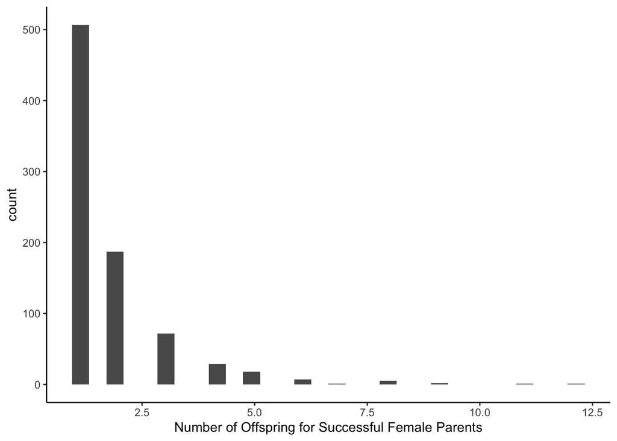

```r
plot_data <- final_pedigree %>% group_by(final_mother) %>% summarise(n = n())
ggplot(data = filter(plot_data, final_mother != "none"))+geom_histogram(aes(x = n))+xlab("Number of Offspring for Successful Female Parents")+theme_classic()
```

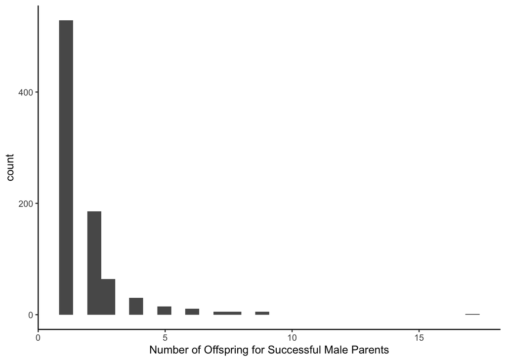

```r
plot_data <- final_pedigree %>% group_by(final_father) %>% summarise(n = n())
ggplot(data = filter(plot_data, final_father != "none"))+geom_histogram(aes(x = n))+xlab("Number of Offspring for Successful Male Parents")+theme_classic()
```

These look good.

# Write Files

```r
pedigree <- final_pedigree %>%
  select(offspring_sample_id, mother = final_mother, father = final_father)
```

Let’s save the final pedigree

```r
pedigree <- final_pedigree %>%
  select(offspring_sample_id, mother = final_mother, father = final_father)

save(pedigree, file = "./pedigree.R")
write_tsv(pedigree, "./pedigree.txt")
```

# Fitness vs Data Quality

Throughout any genotyping process there’s a tradeoff between accuracy and completeness. This has been especially challenging with microsatellites. There has been a desire to tolerate higher missing data than the previous dataset (very little missing data) because I might score ambiguous alleles differently than previous workers. This has caused a new issue though: as the missing data rate goes up, non-exclusion power goes down. We will assess this more directly later, but for now, do we see a positive relationship between fitness and missingness - an indication of a problem, or is there an inverse relationship - our expectation if everything is working as expected.

Ultimately all of the attention paid to NEPs and EFPs is important, but this (TLF ~ missingness) is the best indicator that we have a mjaor problem. Since we are mostly focused on parent level results (e.g. TLF, CRR), if parents have spuriously assigned offspring due to their own missingness, this would strongly effect the results.

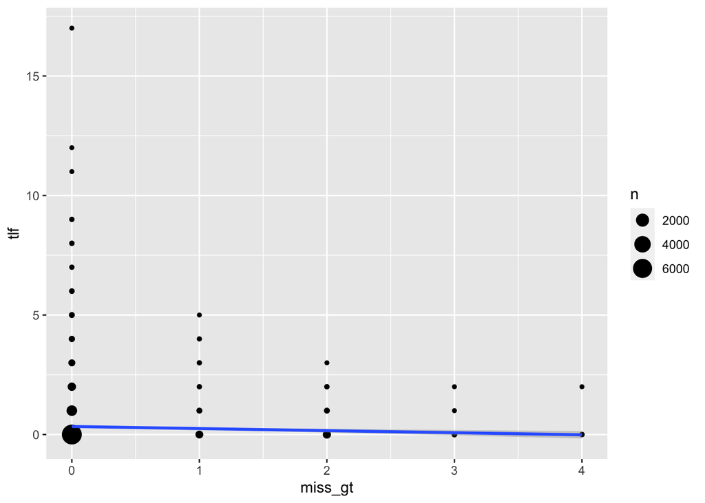

```r
# copied code from the analysis notebook here, which will cause some major issues, if you don't remember to clear your environmnent before starting that notebook! don't use the environment here for that notebook!

dedup <- full_data_1.0 %>%
  group_by(sample_id) %>%
  slice_max(date, with_ties = FALSE) %>%
  ungroup()


parents <- dedup %>%
  filter(cand_parent == TRUE)

father_counts <- pedigree %>%
  group_by(father) %>%
  count() %>%
  rename(parent = father)

mother_counts <- pedigree %>%
  group_by(mother) %>%
  count() %>%
  rename(parent = mother)

parent_counts <- bind_rows(mother_counts, father_counts)
rm(mother_counts)
rm(father_counts)

parents %<>%
  left_join(parent_counts, by = c("sample_id" = "parent")) %>%
  rename(tlf = n) %>%
  mutate(tlf = replace_na(tlf, 0))

ggplot(data = parents, aes(miss_gt, tlf))+geom_count()+geom_smooth(method = "lm")
```

Okay, looks good! individuals with lots of missing data have lower fitness on average than individuals with complete data. Let’s do a better job with the model fit though.

```r
require(MASS)
require(effects)
# here we know that TLF is best fit using the negative binomial distribution and log-link
miss_gt_model <- glm.nb(tlf ~ miss_gt, data = parents)
summary(miss_gt_model)
```

```
##
## Call:
## glm.nb(formula = tlf ~ miss_gt, data = parents, init.theta = 0.2467631678,
##     link = log)
##
## Deviance Residuals:
##     Min       1Q   Median       3Q      Max
## -0.6518  -0.6518  -0.6518  -0.5730   4.0648
##
## Coefficients:
##             Estimate Std. Error z value Pr(>|z|)
## (Intercept) -1.08792    0.02900 -37.516  < 2e-16 ***
## miss_gt     -0.36802    0.07189  -5.119 3.07e-07 ***
## ---
## Signif. codes:  0 '***' 0.001 '**' 0.01 '*' 0.05 '.' 0.1 ' ' 1
##
## (Dispersion parameter for Negative Binomial(0.2468) family taken to be 1)
##
##     Null deviance: 4654.2  on 8984  degrees of freedom
## Residual deviance: 4627.0  on 8983  degrees of freedom
## AIC: 12587
##
## Number of Fisher Scoring iterations: 1
##
##
##               Theta:  0.2468
##           Std. Err.:  0.0115
##
##  2 x log-likelihood:  -12580.9200
```

```r
effects::allEffects(miss_gt_model)
```

```
##  model: tlf ~ miss_gt
##
##  miss_gt effect
## miss_gt
##          0          1          2          3          4
## 0.33691579 0.23318045 0.16138490 0.11169499 0.07730444
```

Yes, higher missingness is associated with lower TLF, suggesting that type I error due to too low of a cutoff for the number of comapred loci (7) is not likely a problem. This makes sense when you think about how the Cervus assignment works. If a given parent has high missingness, the NEP is expected to be high, but two things act to prevent it from gobbling up all the offspring assignments: (1) Each offspring is compared to all parents, (i.e. we choose the best parent for each offspring), (2) if the true parent was sampled, the LOD will be lower for the spurious parent-offspring duo because it is based on less information

Update here: Did a great deal of work examining the impact of missingness on type I and type II error. Calculated cumulative non-exclusion probabilities across range of data missingness and mismatch levels, as well as number of expected false parentages in the pedigree, given the genetic dataset. All these fears are allayed, here’s a summary from that work:

> We expect about 23 spurious assignments given the level of missingness in the data. There are 1,669 assigments in the pedigree, so a little over 1% of the pedigree suffers from type I error, even while making some very conservative assumptions about NEPs. Not bad! In the end, I think the justification used in previous repoorts is also sufficient here: among the individuals with the worst genotyping, the assignments are likely to contain quite a few spurious parent-offspring pairs, but they represent such a small proportion of our total dataset as to be unimportant to the final pedigree.